# RR_PA1

RoelRules

Wednesday, January 17, 2015

# Loading and preprocessing the data

```r
activity = read.csv(unz("./repdata_data_activity.zip", "activity.csv"))
```

# Remove Rows with Missing Data with aggregate(default without NA)

```r
steps.date = aggregate(steps ~ date, data=activity, FUN=sum)
```

# 1 make a barplot(plot1_RR_PA1.png) with steps by date(day)

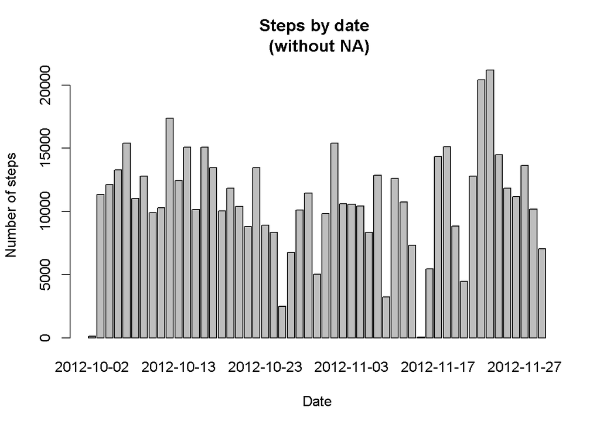

```r
barplot(steps.date$steps, main = "Steps by date \n (without NA)", names.arg=steps.date$date, xlab="Date", ylab="Number of steps")
```

# 2.Calculate and report the mean(10766.19) and median(10765) per total number of steps taken per day

```
[1] 10766.19
```

```
[1] 10765
```

# What is the average daily activity pattern?

# 1.Make a time series plot(plot2_RR_PA1.png,i.e. type = “l”) of the 5-minute interval (x-axis) and the

# average number of steps taken, averaged across all days (y-axis)

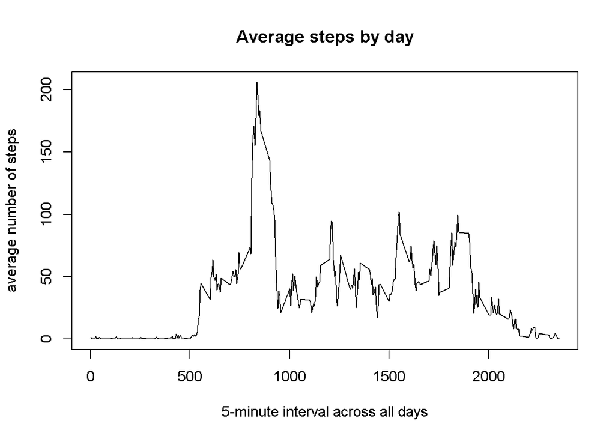

```r
steps.interval =  aggregate(steps ~ interval, data=activity, FUN=mean)

plot(steps.interval, type="l", main = "Average steps by day", xlab = "5-minute interval across all days", ylab= "average number of steps")
```

# 2.Which 5-minute interval, on average across all the days in the dataset, contains the

# maximum number of steps?

```
[1] 835
```

# Calculate and report the total number of missing values in the dataset

# (i.e. the total number of rows with NA’s= 2304 rows)

# 2.Devise a strategy for filling in all of the missing values in the dataset. The

# strategy does not need to be sophisticated. For example, you could use the mean/median

# for that day, or the mean for that 5-minute interval, etc

# I use the means off the 5-min intervalsteps.

# I created a new dataset activity2, filled with this means instead of the missing data.

```r
activity2 = merge(activity, steps.interval, by="interval", suffixes=c("",".y"))
nas = is.na(activity2$steps)
activity2$steps[nas] = activity2$steps.y[nas]
activity2 = activity2[,c(1:3)]
```

# 1.Make a histogram(plot3_RR_PA1.png) of the total number of steps taken each day and Calculate and

# report the mean and median total number of steps taken per day. Do these values differ from the

# estimates from the first part of the assignment?

# What is the impact of imputing missing data on the estimates of the total daily number of steps?

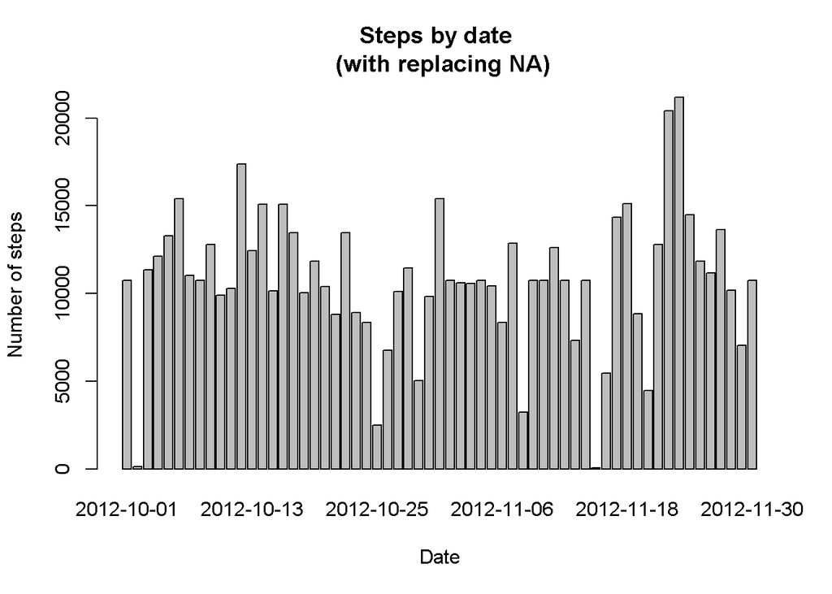

```r
steps.date <- aggregate(steps ~ date, data=activity2, FUN=sum)

barplot(steps.date$steps, names.arg=steps.date$date,
main = "Steps by date \n (with replacing NA)",xlab="Date", ylab="Number of steps")
```

```r
mean(steps.date$steps)
```

```
[1] 10766.19
```

```r
median(steps.date$steps)
```

```
[1] 10766.19
```

# Mean=10766.19 and median= 10766.19 The impact of the missing data seems rather low, at least when

# estimating the total number of steps per day.

# Are there differences in activity patterns between weekdays and weekends?

# 1.Create a new factor variable in the dataset with two levels – “weekday” and “weekend” indicating

# whether a given date is a weekday or weekend day.

```r
daytype = function(date) {
  if (weekdays(as.Date(date)) %in% c("zaterdag", "zondag", "Saturday","Sunday")) {
    "weekend"
  } else {
    "weekday"
  }
}
activity2$daytype = as.factor(sapply(activity2$date, daytype))
```

# 1.Make a panel plot containing a time series plot (i.e. type = “l” ) of the 5-minute interval (x-axis) # and the average number of steps taken, averaged across all weekday days or weekend days (y-axis).

# Aggregate activity2 by steps as a function of interval + day

```r
stepsByDay = aggregate(activity2$steps ~ activity2$interval + activity2$day, activity2, mean)
```

# Rename the column names

```r
names(stepsByDay) = c("interval", "day", "steps")
```

# Plot(plot4_RR_PA1.png) weekday versus weekend steps

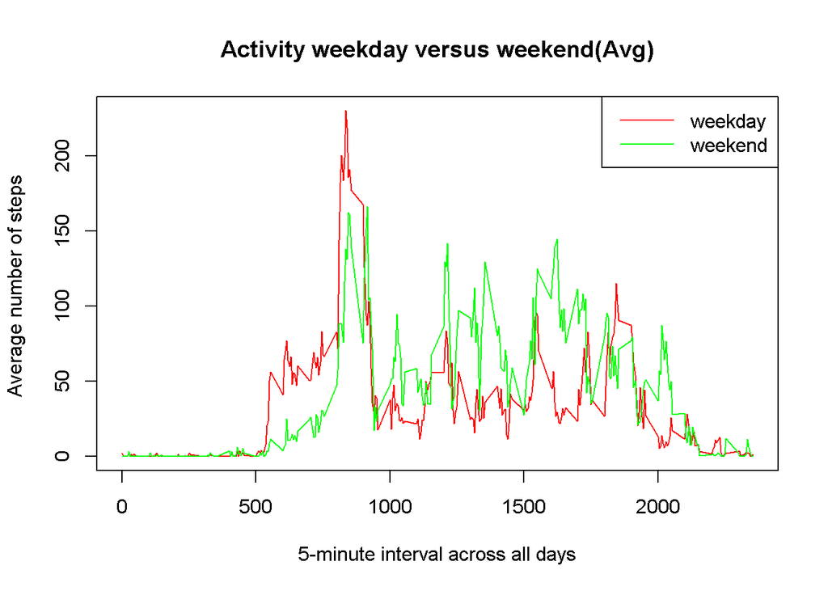

```r
par(mfrow=c(1,1))
with(stepsByDay, plot(steps ~ interval, type="n", main="Activity weekday versus weekend(Avg)",
xlab ="5-minute interval across all days",   ylab = "Average number of steps "))
with(stepsByDay[stepsByDay$day == "weekday",], lines(steps ~ interval, type="l", col="red"))
with(stepsByDay[stepsByDay$day == "weekend",], lines(steps ~ interval, type="l", col="green" ))
legend("topright", lty=c(1,1), col = c("red", "green"), legend = c("weekday", "weekend"), seg.len=3)
```

# The walking person likes mostly activ on the weekends.Only on weekdays the activity starts earlier.